# Lab 1: Getting Started

POLS 3316, Summer 2022, University of Houston, Instructor: Tom Hanna

## We’re going to start by loading some data!

This data is actually built into R in a package called “cars,” but we want to practice loading it from a file. (Later, we’ll practice loading data from the “iris” R package directly.) While loading and examining this simple data set, we’ll look at some basic R concepts like *objects*, *data types*, *variables*, *observations*, *commands*, and *functions*. We will also briefly discuss good *work flow*, which is often considered an advanced topic but actually makes life simpler if you observe it from the start. Finally, we’ll look at some summary statistics and graphical representations or plots.

## Loading data: base R method

We’ll use two methods. The first is the *base R* method, you can use with just the minimum R installation.

With the base R method, we first clear the *Global Environment*, then set a *working directory*. You may have heard directories referred to as “folders.” A directory refers to a specific section of your computer’s disk drive, the permanent storage that remains even if you turn the computer off.

```r
#This is a comment
#Comments can go on their own line, or after a line of actual code

rm(list = ls()) #this clears the Global Environment

setwd("~/3 - R Studio Projects/pols3316-summer2022") #This sets the working directory
#setwd("/cloud/project") #This sets the working directory
```

With the working directory set, we’re ready to actually load the data. The next line of code actually does multiple things.

First, we create a new *object* called “cars_data”. What is an object? Everything we work on in R is an object - a data structure. When we create a new object, it appears in the upper right *Global Environment*. Once an object is created, it stays there and we can do multiple things with it, including changing the object itself.

Then the *assignment operator* **<-** tells R to assign whatever is to the right of it to the new object to the left of the <-. (For those of you with *python* experience, this is the same as the = in python.)

Last, *read.csv* is an R *command* that tells R to read the file we specify.

```r
setwd("~/3 - R Studio Projects/pols3316-summer2022") #because of #the way R Notebooks work, I have to repeat this command in this #"chunk"
cars_data <- read.csv("./data/cars.csv")
```

## Loading Data: Better method!

This is not the preferred method for working with data. With the working directory method, if you run my script on your computer it probably won’t work. The reason is that your directory structure is unique to your computer. For example, I have all my R work in a directory called “~/3 - R Studio Projects/” which you almost certainly don’t have on your computer.

Second, we don’t want to set a working directory since the *R Studio Project*, which we’ll discuss more later, does this for us. R Studio Projects, especially when used with *Github*, provide a much better organized way of handling your work with the added bonus of a simple way to backup your work to the cloud.

[Jenny Bryan, an R Studio developer and educator,](https://www.tidyverse.org/blog/2017/12/workflow-vs-script/) takes this so seriously that she said:

> If the first line of your R script is

> setwd(“C:”)

> I will come into your office and SET YOUR COMPUTER ON FIRE 🔥.

> If the first line of your R script is

> rm(list = ls())

> I will come into your office and SET YOUR COMPUTER ON FIRE 🔥.

The recommended method is to use an R *package* called *here*. A *package* is really just a collection of pre-written code that someone has produced to do specific things in R. The *here* package is intended to help organize loading and storing data. With *here*, you specify the directory in the command and it is always *relative* to the current directory - no need to name the current directory or to set a working directory. For example, in the following code, the data is in a subdirectory (or subfolder) called “data”.

```r
rm(list = ls()) #this clears the Global Environment
#uncomment the following line the first time to install the "here" #package
#install.packages("here")

library("here") #This loads the here package
cars_data <- read.csv(here("data","cars.csv"))
```

Now that we have some data to work with, let’s take a look.

```r
head(cars_data)
```

|  | speed | dist |
| --- | --- | --- |
| 1 | 4 | 2 |
| 2 | 4 | 10 |
| 3 | 7 | 4 |
| 4 | 7 | 22 |
| 5 | 8 | 16 |
| 6 | 9 | 10 |

In this particular dataset, which is set up in the *wide format* which we will normally use where the columns are *variables* and the rows are specific *observations* of the variables.

The first column is just row numbers added by R for indexing the individual *observations*. In some datasets, there might be a column with observation names such as state names, country names, business names, etc. Since this dataset doesn’t have observation names, the index will allow us to use the information for specific observations or ranges of observations.

## Some simple statistics

We can do simple statistics in R two ways. We can perform math operations or we can use built in R commands or functions. For example, we can find the *mean* or average by dividing the sum by the number of observations or by using the *mean()* function.

First, let’s find the sum of both variables.

```r
#create an object called speed and assign it the value of
#the function sum(cars_data$speed)
#
speed_sum <- sum(cars_data$speed) #the command/function is sum, cars_data is the data #frame and speed is the variable

#print the value of speed_sum to the screen
speed_sum
```

```
## [1] 770
```

```r
#Now let's find the sum of distance
```

Now let’s find the mean, first using math operations then using the build in function.

```r
#create an object called speed_mean and compute it using math #operations
speed_mean <- speed_sum/50

#print speed_mean to the screen
speed_mean
```

```
## [1] 15.4
```

```r
#How would we create a variable called distance_mean and compute #it?
```

Now, let’s do the same thing using the built in function.

```r
#create an object speed_mean2 and compute it with the mean function
speed_mean2 <- mean(cars_data$speed)

#print speed_mean2 to the screen
speed_mean2
```

```
## [1] 15.4
```

```r
#Now let's do the same thing for distance
```

```r
#mode
speed_mode <- mode(cars_data$speed)
speed_mode
```

```
## [1] "numeric"
```

```r
#median
speed_median <- median(cars_data$speed)
speed_median
```

```
## [1] 15
```

```r
#variance
speed_variance <- var(cars_data$speed)

#standard deviation
speed_sd <- sd(cars_data$speed)
speed_sd
```

```
## [1] 5.287644
```

```r
#minimum and maximum
min(cars_data$speed)
```

```
## [1] 4
```

```r
max(cars_data$speed)
```

```
## [1] 25
```

```r
#summary
summary(cars_data$speed)
```

```
##    Min. 1st Qu.  Median    Mean 3rd Qu.    Max.
##     4.0    12.0    15.0    15.4    19.0    25.0
```

## Operations on two variables

R can also perform operations on two variables. Don’t worry about deep understanding here - this is a preview of where we are heading late in the semester.

```r
#correlation between two variables
cor(cars_data$speed,cars_data$dist)
```

```
## [1] 0.8068949
```

```r
#covariance of two variables
cov(cars_data$speed,cars_data$dist)
```

```
## [1] 109.9469
```

And ultimately, we can compute regressions of the relationship between two or more models. Regression gives us two things. First, a formula for predicting the value of one variable based on one or more other variables. Second, it can tell us whether the result is truly meaningful - what we call statistically significant - or simply the result of random chance. *Note: This data is meaningless, so the results - especially the plot - are meaningless.*

```r
#OLS regression of two variables
regression_model <- lm(dist ~ speed, data = cars_data)
summary(regression_model)
```

```
##
## Call:
## lm(formula = dist ~ speed, data = cars_data)
##
## Residuals:
##     Min      1Q  Median      3Q     Max
## -29.069  -9.525  -2.272   9.215  43.201
##
## Coefficients:
##             Estimate Std. Error t value Pr(>|t|)
## (Intercept) -17.5791     6.7584  -2.601   0.0123 *
## speed         3.9324     0.4155   9.464 1.49e-12 ***
## ---
## Signif. codes:  0 '***' 0.001 '**' 0.01 '*' 0.05 '.' 0.1 ' ' 1
##
## Residual standard error: 15.38 on 48 degrees of freedom
## Multiple R-squared:  0.6511, Adjusted R-squared:  0.6438
## F-statistic: 89.57 on 1 and 48 DF,  p-value: 1.49e-12
```

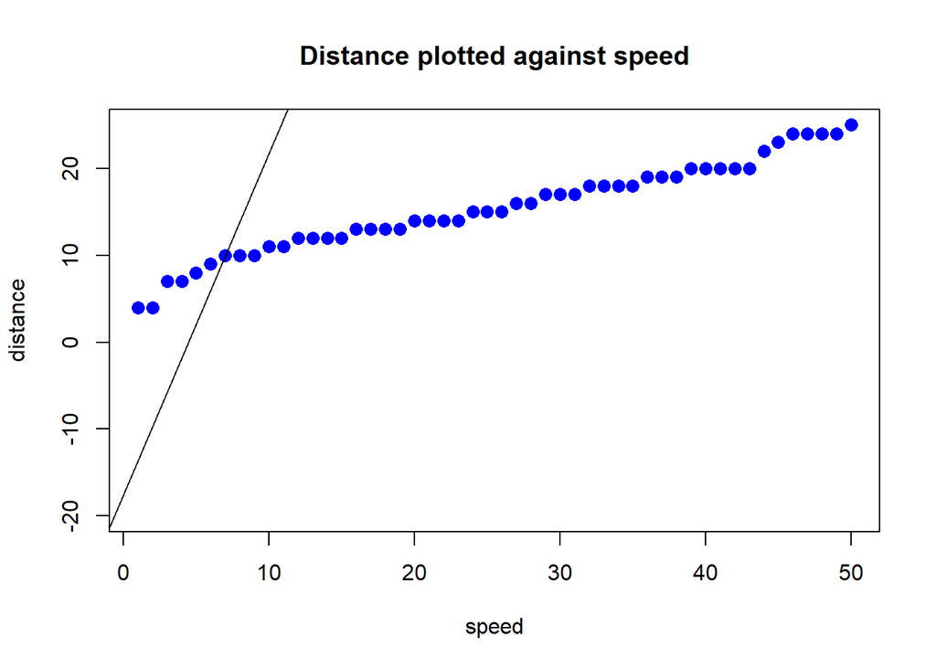

```r
plot(cars_data$speed, cars_data$distance, pch = 16, cex = 1.3, col = "blue", main = "Distance plotted against speed", xlab = "speed", ylab = "distance", ylim=c(-20,25))
abline(lm(cars_data$dist ~ cars_data$speed))
```

## Simple plots

We can do some other plots with the built in plotting function. Later, there are more advanced *packages* like *ggplot2*, *coefplot*, *sJplot*, and many more that will let you produce really beautiful data visualizations. Other packages like *shiny* will help you share these in print or even build web applications.

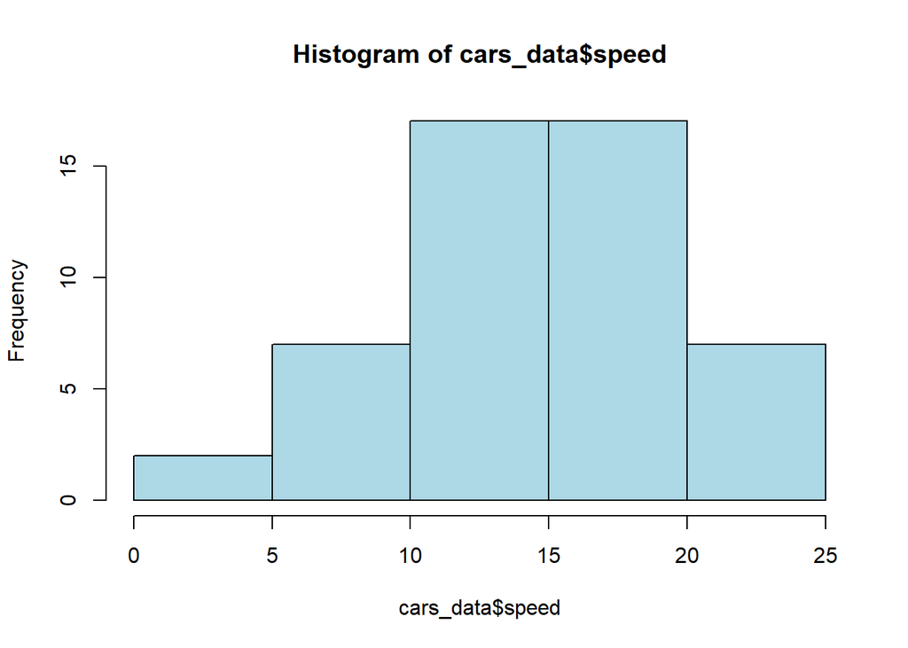

```r
#plot histograms
hist(cars_data$speed, col = "lightblue")
```

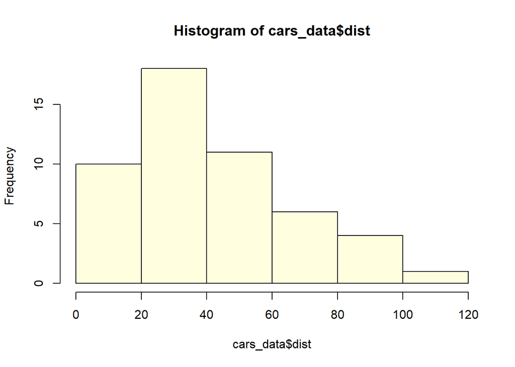

```r
hist(cars_data$dist, col = "lightyellow")
```

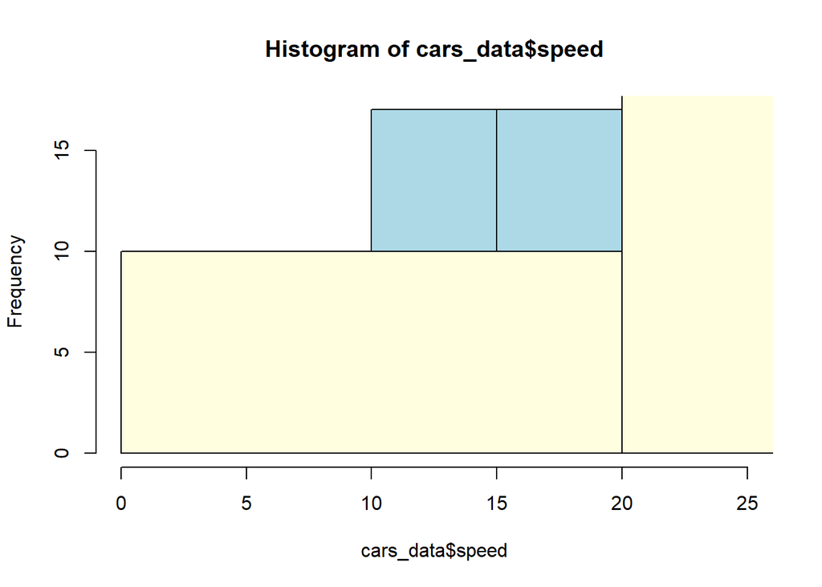

```r
#plot a combined histogram
hist(cars_data$speed, col = "lightblue")

hist(cars_data$dist, col = "lightyellow", add = TRUE)
```

To show a couple of other plotting functions, I’m going to use a built in dataset from R. This data has information on iris flowers. Specifically, we’ll use the data on the length and width of the petals and sepals. (Sepals are the green leaf like structures around the petals of the flower.) [Checkto R Coder for some more advanced plots](https://r-coder.com/correlation-plot-r/)

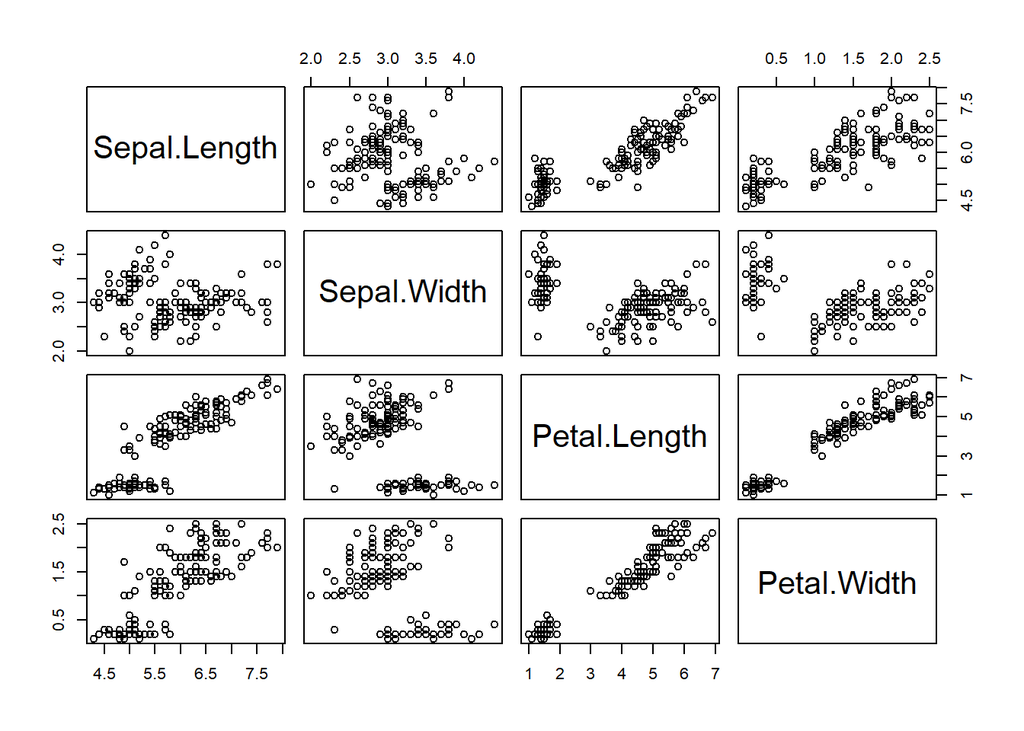

```r
# Numerical variables from the iris package
iris_data <- iris[, 1:4]

pairs(iris_data)
```

## Math operations

R can perform basic mathematical operations, as well as some that are not so basic. This can be useful when you just need to quickly check something about a result by typing a math operation in the *console* (the lower left corner). You can also include math operations in programs and functions. For example, it’s possible to create new variables using math operations.

```r
#basic math
1 + 1
```

```
## [1] 2
```

```r
2 / 2
```

```
## [1] 1
```

```r
1 * 5
```

```
## [1] 5
```

```r
1 - 1
```

```
## [1] 0
```

```r
#create objects based on a math operation

new_object <- 1 + 1 - 5
new_object
```

```
## [1] -3
```

```r
new_object2 <- 5 - 1 - 1
new_object2
```

```
## [1] 3
```

We can even perform math operations on objects.

```r
#perform a math operation on the new objects to create a third #object
new_object3 <- new_object + new_object2

#print result to the screen
new_object
```

```
## [1] -3
```

And, we can create new variables in data frames using math operations.

```r
#create a new variable for the excess speed over the average #(mean)
cars_data$excess_speed <- cars_data$speed - speed_mean

#look at the head and tail of the data frame with the new variable
head(cars_data)
```

|  | speed | dist | excess_speed |
| --- | --- | --- | --- |
| 1 | 4 | 2 | -11.4 |
| 2 | 4 | 10 | -11.4 |
| 3 | 7 | 4 | -8.4 |
| 4 | 7 | 22 | -8.4 |
| 5 | 8 | 16 | -7.4 |
| 6 | 9 | 10 | -6.4 |

```r
tail(cars_data)
```

|  | speed | dist | excess_speed |
| --- | --- | --- | --- |
| 45 | 23 | 54 | 7.6 |
| 46 | 24 | 70 | 8.6 |
| 47 | 24 | 92 | 8.6 |
| 48 | 24 | 93 | 8.6 |
| 49 | 24 | 120 | 8.6 |
| 50 | 25 | 85 | 9.6 |